# MGT 6203 - Progress Report (Thuy, Eleibny, Leland, Spencer

# Now can explore the data

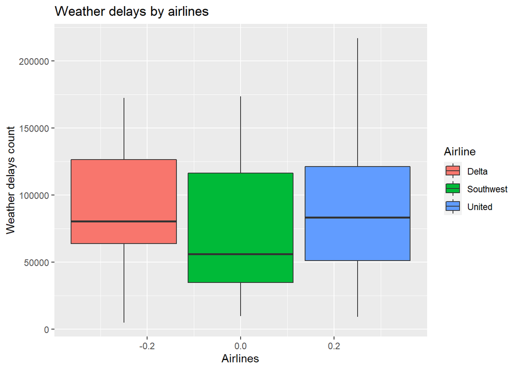

```r
ggplot(combined_qts, aes(y = weather_delay_sum,  fill=Airline))+
  geom_boxplot()+
  labs(x = "Airlines", y= "Weather delays count",
       title ="Weather delays by airlines")
```

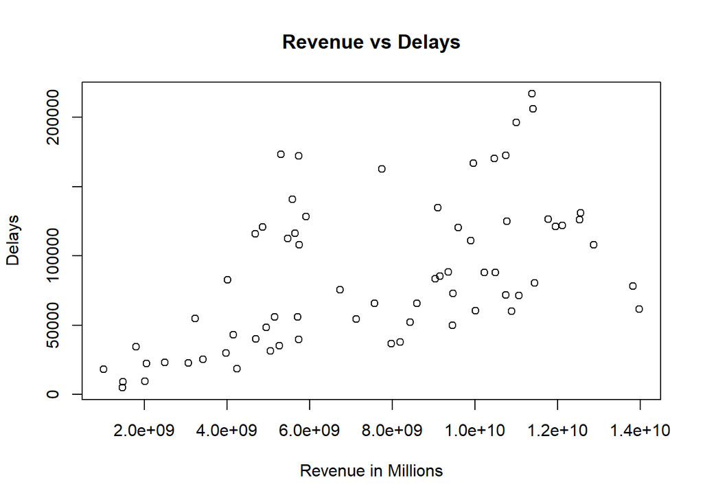

```r
plot(combined_qts$Amount,combined_qts$weather_delay_sum, main="Revenue vs Delays", xlab="Revenue in Millions",ylab="Delays")
```

#From the scatterplot, we observe an apparent relationship between delays and revenue.

# Now, we fit a model to evaluate the data

```r
model <- lm(Amount~Airline+Time+weather_delay_sum, combined_qts)
summary(model)
```

```
##
## Call:
## lm(formula = Amount ~ Airline + Time + weather_delay_sum, data = combined_qts)
##
## Residuals:
##        Min         1Q     Median         3Q        Max
## -1.675e+09 -5.207e+08  7.157e+07  4.516e+08  2.397e+09
##
## Coefficients:
##                     Estimate Std. Error t value Pr(>|t|)
## (Intercept)        9.084e+09  7.678e+08  11.831 5.89e-15 ***
## AirlineSouthwest  -4.560e+09  3.121e+08 -14.610  < 2e-16 ***
## AirlineUnited     -9.548e+08  2.999e+08  -3.184 0.002739 **
## Time20172          1.300e+09  8.417e+08   1.545 0.129845
## Time20173          1.260e+09  8.328e+08   1.513 0.137670
## Time20174          9.462e+08  8.523e+08   1.110 0.273260
## Time20181          5.274e+08  8.300e+08   0.635 0.528554
## Time20182          1.935e+09  8.333e+08   2.322 0.025163 *
## Time20183          1.945e+09  8.580e+08   2.266 0.028638 *
## Time20184          1.583e+09  8.405e+08   1.883 0.066577 .
## Time20191          9.158e+08  8.318e+08   1.101 0.277175
## Time20192          2.382e+09  8.588e+08   2.773 0.008239 **
## Time20193          2.290e+09  8.602e+08   2.662 0.010962 *
## Time20194          1.981e+09  8.501e+08   2.331 0.024641 *
## Time20201         -3.947e+08  8.728e+08  -0.452 0.653453
## Time20202         -5.951e+09  9.206e+08  -6.464 8.53e-08 ***
## Time20203         -4.854e+09  8.926e+08  -5.438 2.54e-06 ***
## Time20204         -4.158e+09  9.011e+08  -4.615 3.68e-05 ***
## Time20211         -4.189e+09  8.730e+08  -4.798 2.05e-05 ***
## Time20212         -1.885e+09  8.341e+08  -2.260 0.029088 *
## Time20213         -3.053e+08  8.338e+08  -0.366 0.716090
## Time20214          2.259e+08  8.637e+08   0.262 0.794959
## Time20221         -1.785e+08  8.459e+08  -0.211 0.833907
## Time20222          3.450e+09  8.311e+08   4.151 0.000158 ***
## Time20223          4.642e+09  9.375e+08   4.952 1.25e-05 ***
## weather_delay_sum  2.095e+03  4.339e+03   0.483 0.631720
## ---
## Signif. codes:  0 '***' 0.001 '**' 0.01 '*' 0.05 '.' 0.1 ' ' 1
##
## Residual standard error: 1.016e+09 on 42 degrees of freedom
## Multiple R-squared:  0.9468, Adjusted R-squared:  0.9152
## F-statistic: 29.91 on 25 and 42 DF,  p-value: < 2.2e-16
```

In this first model, we fitted the Airline, Time(quarter) and the count of weather related delays as predictors, and the Amount variable as dependent. As we can see from the model’s summary, the Airline variable has statistical significance, for all 3 values. Delta is the intercept. The Time(quarter) is not significant for 2017, It start increasing statistical significance after 2018. The impact is more noticeable in 2020, as evidence by the p-value close to zero on those quarters. As per the Count of weather related delays predictor, the model does not consider it as Statistically significant, with a pvalue of 0.63172. The R-square of the model is 0.947, which indicates that the model can explain approximately 95% of variability of the revenue.

# Let’s see if there is a collinearity issue on the model

```r
vif(model)
```

```
##                       GVIF Df GVIF^(1/(2*Df))
## Airline           1.092842  2        1.022444
## Time              3.352977 22        1.027878
## weather_delay_sum 3.379880  1        1.838445
```

```r
max(10, 1/(1-summary(model)$r.squared))
```

```
## [1] 18.8019
```

the VIF for all predictors is below the threshold 18.8. It indicates the model does not have a multicollinearity problem.

# Let’s evaluate the correlation on the numeric variables

```r
cor(combined_qts[, c('Amount','weather_delay_sum')])
```

```
##                      Amount weather_delay_sum
## Amount            1.0000000         0.5431132
## weather_delay_sum 0.5431132         1.0000000
```

The maximum correlation between weather delay and Revenue amount is 0.543